# cupstone project

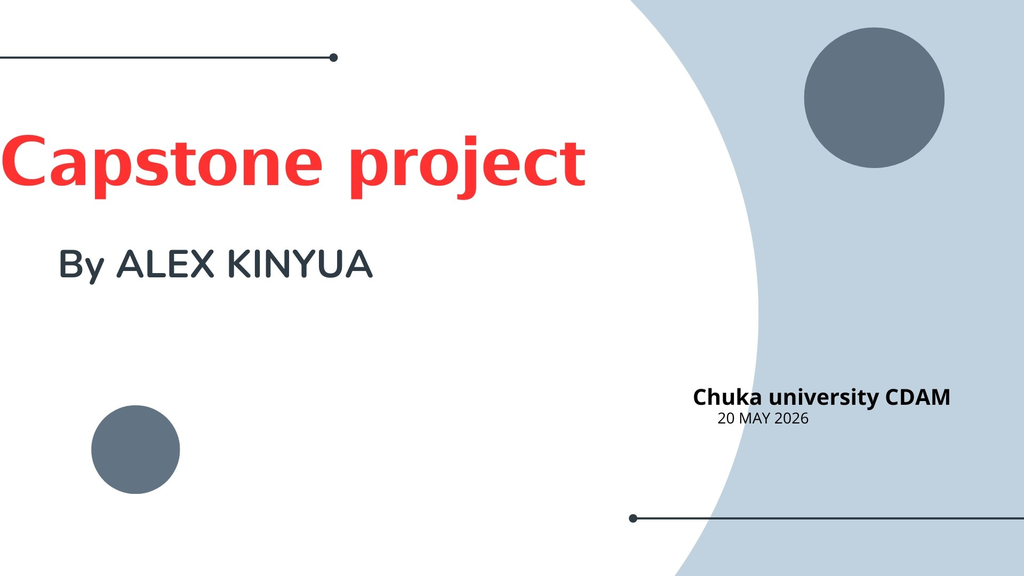

## Project Overview

#### This project demonstrates how data science is used in healthcare to analyze medical insurance data

and understand the factors that influence healthcare costs. The analysis focuses on identifying relationships between demographic characteristics, lifestyle habits, and insurance charges to generate meaningful insights for healthcare decision-making and predictive modeling. The project uses a structured healthcare insurance dataset containing demographic information, health indicators, family coverage details, geographic location, and medical insurance expenses. Through data cleaning, exploratory data analysis (EDA) and visualization, the project aims to uncover patterns that explain variations in healthcare costs among insured individuals.

## Project Objectives

The project seeks to: • Clean and preprocess healthcare insurance data for analysis. • Explore patterns and trends in medical insurance charges. • Investigate how demographic factors such as age and gender influence healthcare expenses. • Examine the impact of lifestyle factors such as smoking habits and Body Mass Index (BMI) on insurance costs. • Analyze family-related variables such as the number of dependents covered by insurance. • Compare insurance charges across different geographic regions.

# importing liblaries

```python
import pandas as pd
import numpy as np
import seaborn as sns
import matplotlib.pyplot as plt
import os
from sklearn.preprocessing import LabelEncoder
import warnings
warnings.simplefilter(action='ignore')
```

# loading insurance data

```python
hd=pd.read_csv('insurance_data.csv')
hd.head(5)
```

|  | age | sex | bmi | children | smoker | region | charges |
| --- | --- | --- | --- | --- | --- | --- | --- |
| 0 | 19 | female | 27.900 | 0 | yes | southwest | 16884.92400 |
| 1 | 18 | male | 33.770 | 1 | no | southeast | 1725.55230 |
| 2 | 28 | male | 33.000 | 3 | no | southeast | 4449.46200 |
| 3 | 33 | male | 22.705 | 0 | no | northwest | 21984.47061 |
| 4 | 32 | male | 28.880 | 0 | no | northwest | 3866.85520 |

```python
#data cleaning
hd.isnull().sum() #checking the null values
```

```
age         0
sex         0
bmi         0
children    0
smoker      0
region      0
charges     0
dtype: int64
```

```python
# checking for duplicates
print(f"\nNumber of duplicated rows: {hd.duplicated().sum()}")
print(f"Any duplicates present: {hd.duplicated().any()}")
```

```
Number of duplicated rows: 1
Any duplicates present: True
```

### checking the data types

```python
hd.info()
```

```
<class 'pandas.core.frame.DataFrame'>
RangeIndex: 1338 entries, 0 to 1337
Data columns (total 7 columns):
 #   Column    Non-Null Count  Dtype
---  ------    --------------  -----
 0   age       1338 non-null   int64
 1   sex       1338 non-null   object
 2   bmi       1338 non-null   float64
 3   children  1338 non-null   int64
 4   smoker    1338 non-null   object
 5   region    1338 non-null   object
 6   charges   1338 non-null   float64
dtypes: float64(2), int64(2), object(3)
memory usage: 73.3+ KB
```

```python
# conversion of data types to, objects to categorical
```

```python
hd['sex'] = hd['sex'].astype('category')
hd['region'] = hd['region'].astype('category')
hd['smoker'] = hd['smoker'].astype('category')
```

```python
hd.info()
```

```
<class 'pandas.core.frame.DataFrame'>
RangeIndex: 1338 entries, 0 to 1337
Data columns (total 7 columns):
 #   Column    Non-Null Count  Dtype
---  ------    --------------  -----
 0   age       1338 non-null   int64
 1   sex       1338 non-null   category
 2   bmi       1338 non-null   float64
 3   children  1338 non-null   int64
 4   smoker    1338 non-null   category
 5   region    1338 non-null   category
 6   charges   1338 non-null   float64
dtypes: category(3), float64(2), int64(2)
memory usage: 46.3 KB
```

```python
#hd=pd.get_dummies(hd, columns=[],drop_first=True, dtype=int) # data encoding
```

## Explanatory data analysis

```python
# summary statistics
summary_stats = hd.describe()
summary_stats
```

|  | age | bmi | children | charges |
| --- | --- | --- | --- | --- |
| count | 1338.000000 | 1338.000000 | 1338.000000 | 1338.000000 |
| mean | 39.207025 | 30.663397 | 1.094918 | 13270.422265 |
| std | 14.049960 | 6.098187 | 1.205493 | 12110.011237 |
| min | 18.000000 | 15.960000 | 0.000000 | 1121.873900 |
| 25% | 27.000000 | 26.296250 | 0.000000 | 4740.287150 |
| 50% | 39.000000 | 30.400000 | 1.000000 | 9382.033000 |
| 75% | 51.000000 | 34.693750 | 2.000000 | 16639.912515 |
| max | 64.000000 | 53.130000 | 5.000000 | 63770.428010 |

```python
# checking categorical summary
categorical_summary = hd.describe(include=['category'])
categorical_summary
```

|  | sex | smoker | region |
| --- | --- | --- | --- |
| count | 1338 | 1338 | 1338 |
| unique | 2 | 2 | 4 |
| top | male | no | southeast |
| freq | 676 | 1064 | 364 |

#### checking for outliers using box plots

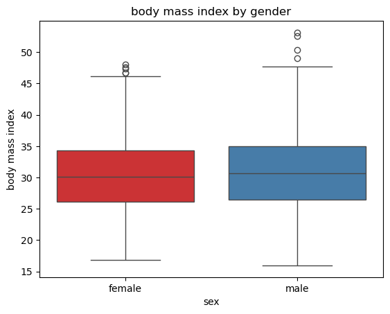

```python
#box plot for body mass index
sns.boxplot(data=hd, x='sex', y='bmi', palette='Set1')
plt.title("body mass index by gender")
plt.xlabel("sex")
plt.ylabel("body mass index")
plt.show()
```

##### box plot for charges vs sex

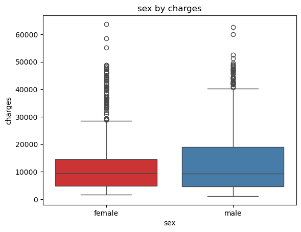

```python
sns.boxplot(data=hd, x='sex', y='charges', palette='Set1')
plt.title("sex by charges")
plt.xlabel("sex")
plt.ylabel("charges")
plt.show()
```

#### box plot for all mumerical variables

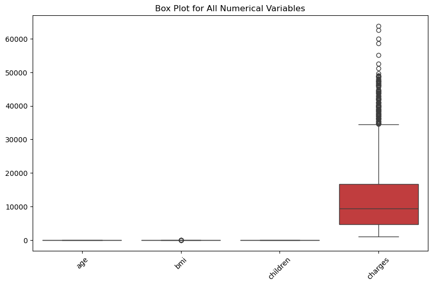

```python
# Create box plots for all numerical variables
plt.figure(figsize=(10, 6))
sns.boxplot(data=hd)

plt.xticks(rotation=45)  # Rotate x-axis labels if needed
plt.title("Box Plot for All Numerical Variables")
plt.show()
```

#### Create box plots for insuarance charges

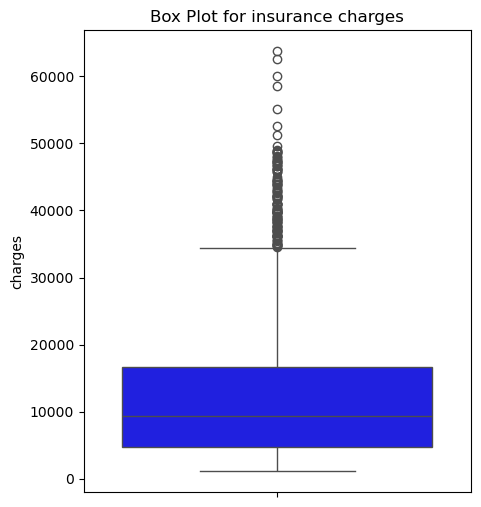

```python
plt.figure(figsize=(5, 6))
sns.boxplot(data=hd, y='charges', color='blue')

# Customize plot
plt.xticks(rotation=45)  # Rotate x-axis labels if needed
plt.title("Box Plot for insurance charges")
plt.show()
```

##### Create box plots for body mass index

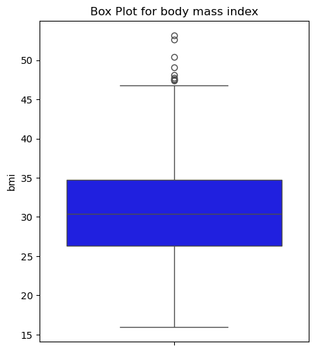

```python
plt.figure(figsize=(5, 6))
sns.boxplot(data=hd, y='bmi', color='blue')

# Customize plot
plt.xticks(rotation=45)  # Rotate x-axis labels if needed
plt.title("Box Plot for body mass index")
plt.show()
```

#### removing outliers using IQR

```python
#removing outliers
#on bmi
def remove_outliers_iqr(hd, bmi):
    Q1 = hd[bmi].quantile(0.25)
    Q3 = hd[bmi].quantile(0.75)
    IQR = Q3 - Q1

    lower_bound = Q1 - 1.5 * IQR
    upper_bound = Q3 + 1.5 * IQR

    return hd[(hd[bmi] >= lower_bound) & (hd[bmi] <= upper_bound)]
hd=remove_outliers_iqr(hd, 'bmi')
```

```python
#removing outliers
#on charges
def remove_outliers_iqr(hd, charges):
    Q1 = hd[charges].quantile(0.25)
    Q3 = hd[charges].quantile(0.75)
    IQR = Q3 - Q1

    lower_bound = Q1 - 1.5 * IQR
    upper_bound = Q3 + 1.5 * IQR

    return hd[(hd[charges] >= lower_bound) & (hd[charges] <= upper_bound)]
hd=remove_outliers_iqr(hd, 'charges')
```

#### checking for outliers on charges

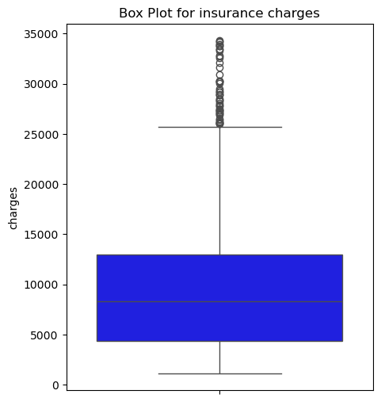

```python
plt.figure(figsize=(5, 6))
sns.boxplot(data=hd, y='charges', color='blue')

# Customize plot
plt.xticks(rotation=45)  # Rotate x-axis labels if needed
plt.title("Box Plot for insurance charges")
plt.show()
```

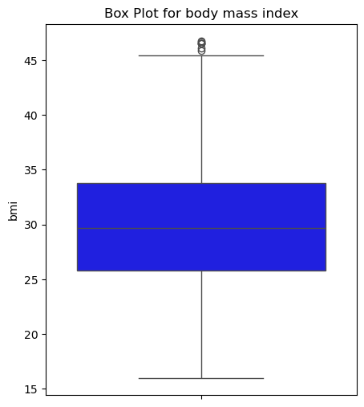

```python
plt.figure(figsize=(5, 6))
sns.boxplot(data=hd, y='bmi', color='blue')

# Customize plot
plt.xticks(rotation=45)  # Rotate x-axis labels if needed
plt.title("Box Plot for body mass index")
plt.show()
```

```python
#removing outliers
#on charges
def remove_outliers_iqr(hd, charges):
    Q1 = hd[charges].quantile(0.25)
    Q3 = hd[charges].quantile(0.75)
    IQR = Q3 - Q1

    lower_bound = Q1 - 1.5 * IQR
    upper_bound = Q3 + 1.5 * IQR

    return hd[(hd[charges] >= lower_bound) & (hd[charges] <= upper_bound)]
hd=remove_outliers_iqr(hd, 'charges')
```

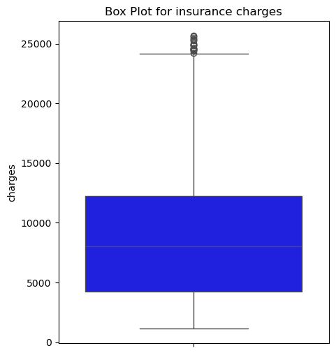

```python
plt.figure(figsize=(5, 6))
sns.boxplot(data=hd, y='charges', color='blue')

# Customize plot
plt.xticks(rotation=45)  # Rotate x-axis labels if needed
plt.title("Box Plot for insurance charges")
plt.show()
```

# DEMOGRAPHIC TRENDS

## Age vs healthcare expenses

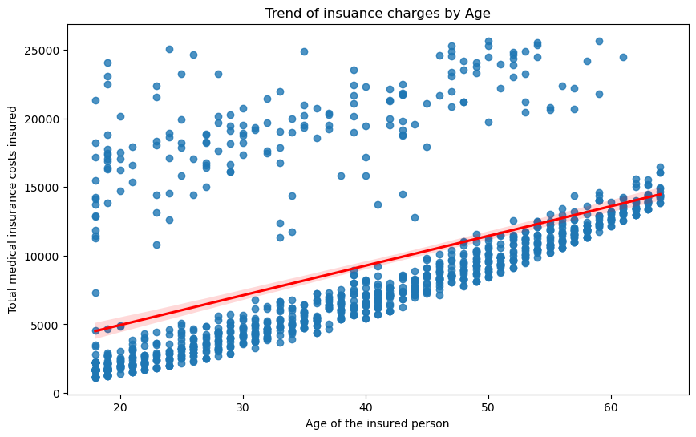

```python
plt.figure(figsize=(10, 6))
sns.regplot(x='age',y='charges', data=hd, line_kws={'color':'red'})
plt.title('Trend of insuance charges by Age')
plt.xlabel('Age of the insured person')
plt.ylabel('Total medical insurance costs insured')
plt.show()
```

### summary

#### The regression analysis reveals the correlation between age and insurance charges, likely showing an upward trend where older individuals incure higher medical costs, medical chareges skyrockets with age

## life style trends:

#### Effect of BMI and smoking

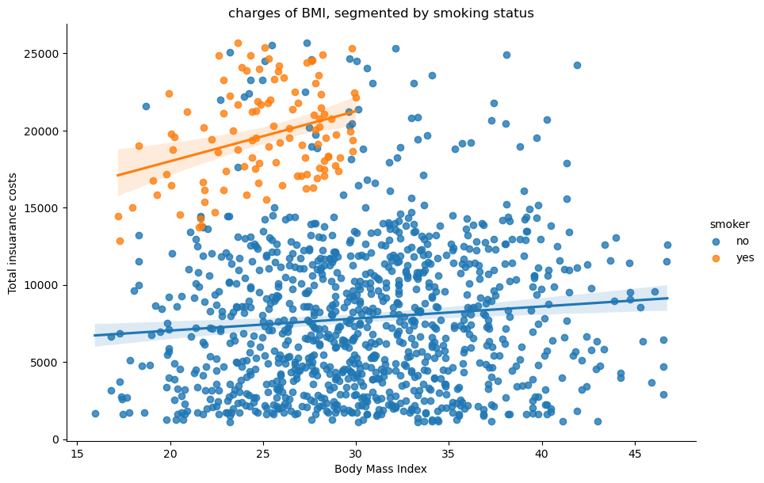

```python
sns.lmplot(x='bmi', y='charges', hue='smoker', data=hd, aspect=1.5, height=6)
plt.title('charges of BMI, segmented by smoking status')
plt.xlabel('Body Mass Index')
plt.ylabel('Total insuarance costs')
plt.show()
```

# Explanation

```python
## family trend, number of children vs health charges
```

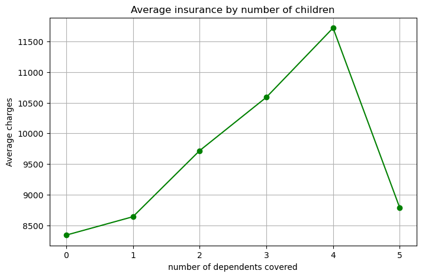

```python
family_trend=hd.groupby('children')['charges'].mean()
plt.figure(figsize=(8, 5))
family_trend.plot(kind='line', marker='o', color='green')
plt.title('Average insurance by number of children')
plt.xlabel('number of dependents covered')
plt.ylabel('Average charges')
plt.grid(True)
plt.show()
```